# Hw1

Rachel Kaufman

2023-01-12

```r
library(tidyverse)
library(dplyr)
twitch_data <- read_csv("twitchdata-update.csv")
library(janitor)
twitch_data <- clean_names(twitch_data)
colnames(twitch_data)
```

```
##  [1] "channel"             "watch_time_minutes"  "stream_time_minutes"
##  [4] "peak_viewers"        "average_viewers"     "followers"
##  [7] "followers_gained"    "views_gained"        "partnered"
## [10] "mature"              "language"
```

Q1

```r
View(twitch_data)
#looking at the data
twitch_data %>%
  select(average_viewers, followers)
```

```
## # A tibble: 1,000 × 2
##    average_viewers followers
##              <dbl>     <dbl>
##  1           27716   3246298
##  2           25610   5310163
##  3           10976   1767635
##  4            7714   3944850
##  5           29602   8938903
##  6           42414   1563438
##  7           24181   4074287
##  8           18985    508816
##  9           22381   3530767
## 10           12377   2607076
## # … with 990 more rows
```

```r
#summarizing the data
twitch_data %>%
  select(average_viewers, followers) %>%
  summary()
```

```
##  average_viewers    followers
##  Min.   :   235   Min.   :   3660
##  1st Qu.:  1458   1st Qu.: 170546
##  Median :  2425   Median : 318063
##  Mean   :  4781   Mean   : 570054
##  3rd Qu.:  4786   3rd Qu.: 624332
##  Max.   :147643   Max.   :8938903
```

In terms of what I notice, the range for minimum and maximum followers is incredibly wide distribution, and the mean is a lot higher than the median. As for the average viewers, it is noticeably less than the # of followers. The mean is also higher than the median, with a large distribution in range. Comparing their summary statistics does not tell me much about predictive power, but I can look at a scatter plot to help me out to look at their relationship :)

```r
## install.packages("hrbrthemes")
library(hrbrthemes)
```

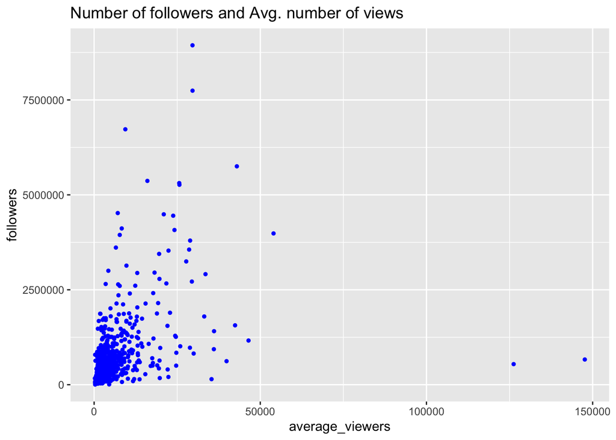

```r
ggplot(twitch_data, aes(average_viewers, followers)) +
  geom_point(size = 1, color = "blue") +
  labs(title = "Number of followers and Avg. number of views")
```

There seems to be some sort of correlation, with a few wonky outliers. A lot of the data points are all in the bottom left, meaning they are stacked on each other and difficult to interpret, so log transform will give us a better understanding of the distribution.

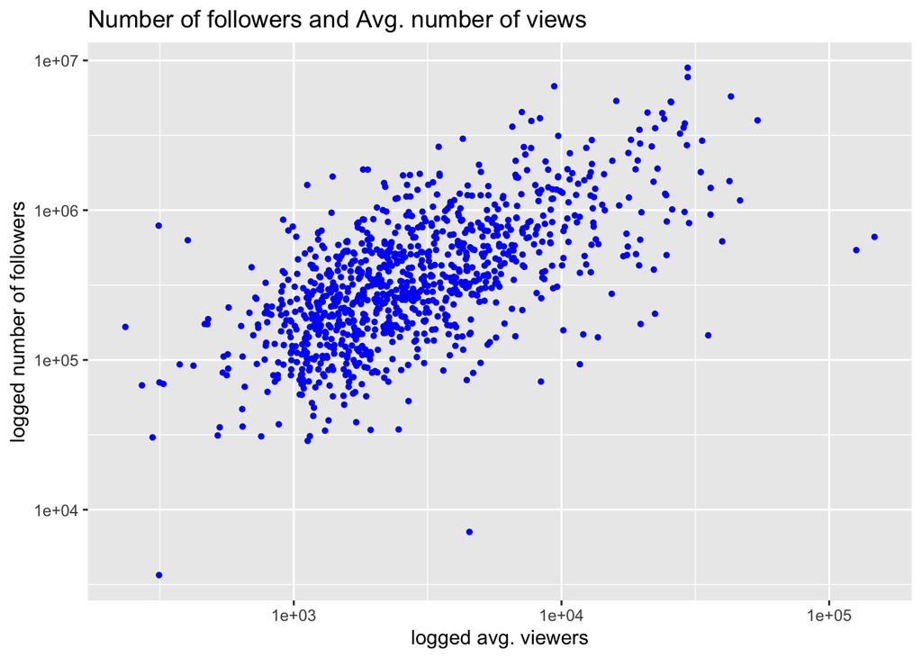

```r
ggplot(twitch_data, aes(average_viewers, followers)) +
  geom_point(size = 1, color = "blue") +
  labs(title = "Number of followers and Avg. number of views",
       x = "logged avg. viewers",
       y = "logged number of followers") +
  scale_x_log10() +
  scale_y_log10()
```

Phew! Looks way better. There definitely seems to be a correlation.

Adding the transformations as their own new columns to our data set:

```r
twitch_data <- twitch_data %>%
  mutate(log_viewers = log10(average_viewers),
         log_followers = log10(followers))
View(twitch_data)
```

### **Q2**

```r
fit1 <- lm(formula = log_viewers~log_followers,
   data = twitch_data)
library(broom)
tidy(fit1)
```

```
## # A tibble: 2 × 5
##   term          estimate std.error statistic   p.value
##   <chr>            <dbl>     <dbl>     <dbl>     <dbl>
## 1 (Intercept)      0.198    0.125       1.58 1.15e-  1
## 2 log_followers    0.588    0.0226     26.0  1.69e-114
```

```r
##interpret your coefficients
1.1^{0.588} #1.1 -> is the 10%, this is just transforming the log into % for interpreting
```

```
## [1] 1.057643
```

This tells us with that when we see a 10% increase in number of followers, we see a 5.8% increase in average viewers

### **Q3**

```r
##fitted values
pred_data <- augment(fit1)
glimpse(pred_data)
```

```
## Rows: 1,000
## Columns: 8
## $ log_viewers   <dbl> 4.442731, 4.408410, 4.040444, 3.887280, 4.471321, 4.6275…
## $ log_followers <dbl> 6.511388, 6.725108, 6.247393, 6.596030, 6.951284, 6.1940…
## $ .fitted       <dbl> 4.029761, 4.155534, 3.874400, 4.079572, 4.288638, 3.8430…
## $ .resid        <dbl> 0.4129697, 0.2528757, 0.1660436, -0.1922928, 0.1826833, …
## $ .hat          <dbl> 0.006194481, 0.008694557, 0.003782169, 0.007126066, 0.01…
## $ .sigma        <dbl> 0.3085580, 0.3087321, 0.3087919, 0.3087764, 0.3087820, 0…
## $ .cooksd       <dbl> 0.0056128779, 0.0029688873, 0.0005513456, 0.0014026033, …
## $ .std.resid    <dbl> 1.3420109, 0.8227954, 0.5389316, -0.6251793, 0.5953620, …
```

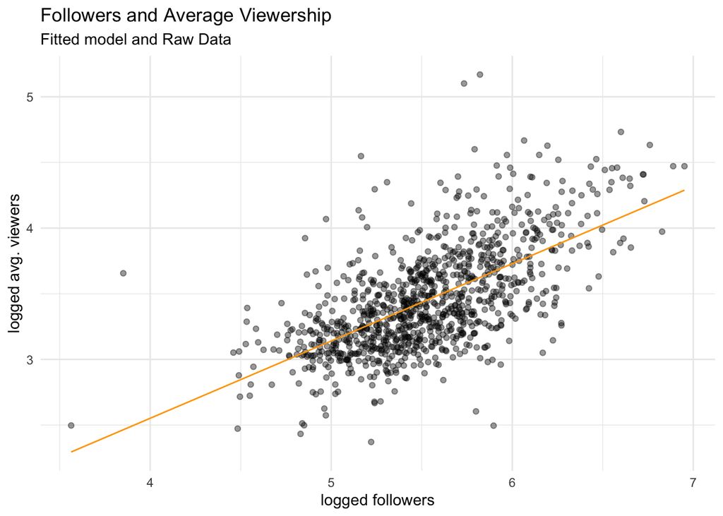

```r
pred_data %>%
  ggplot(aes(log_followers,
             log_viewers)) +
  geom_jitter(alpha = 0.4) +
  geom_line(aes(x = log_followers,
                y = .fitted),
            col = "orange") +
  theme_minimal() +
  labs(title = "Followers and Average Viewership",
       subtitle = "Fitted model and Raw Data",
       x = "logged followers",
       y = "logged avg. viewers")
```

This shows us our predicted values given the line of bestfit.

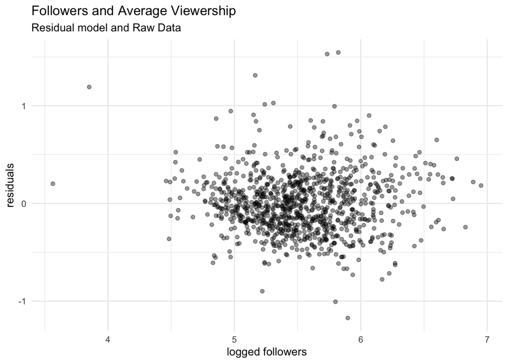

```r
pred_data %>%
  ggplot(aes(log_followers,
             .resid)) +
  geom_jitter(alpha = 0.4) +
  theme_minimal() +
  labs(title = "Followers and Average Viewership",
       subtitle = "Residual model and Raw Data",
       x = "logged followers",
       y = "residuals")
```

Q4 looking at language and avg. viewers. The goal of this is to work with a categorical variable to find predictive values of a continuous variable. Let’s look at the raw data…

```r
#lets take a look at the variables we are interested in.
twitch_data %>%
  select(language, average_viewers)
```

```
## # A tibble: 1,000 × 2
##    language   average_viewers
##    <chr>                <dbl>
##  1 English              27716
##  2 English              25610
##  3 Portuguese           10976
##  4 English               7714
##  5 English              29602
##  6 English              42414
##  7 English              24181
##  8 English              18985
##  9 English              22381
## 10 English              12377
## # … with 990 more rows
```

```r
#i want to be able to look at the # of different languages...
twitch_data %>%
 count(language) %>%
  arrange(desc(n))
```

```
## # A tibble: 21 × 2
##    language       n
##    <chr>      <int>
##  1 English      485
##  2 Korean        77
##  3 Russian       74
##  4 Spanish       68
##  5 French        66
##  6 Portuguese    61
##  7 German        49
##  8 Chinese       30
##  9 Turkish       22
## 10 Italian       17
## # … with 11 more rows
```

So I have got 21 languages, with English having the highest count of 485.

Lets use `summary()` to look at some descriptive statistics:

```r
twitch_data %>%
  select(language, average_viewers) %>%
  summary()
```

```
##    language         average_viewers
##  Length:1000        Min.   :   235
##  Class :character   1st Qu.:  1458
##  Mode  :character   Median :  2425
##                     Mean   :  4781
##                     3rd Qu.:  4786
##                     Max.   :147643
```

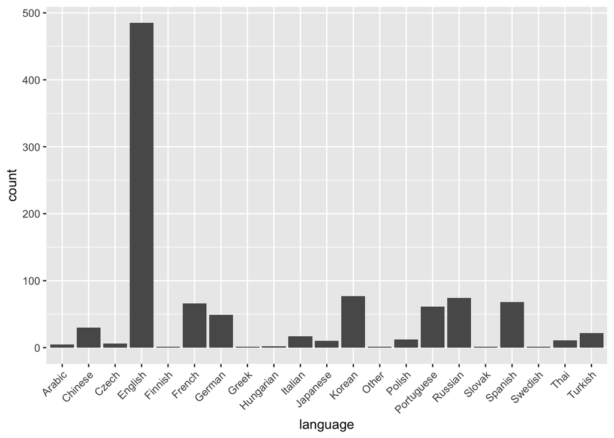

```r
##visualizing language distribution
ggplot(twitch_data, aes(x = language)) +
  geom_bar() +
  theme(axis.text.x = element_text(angle = 45, hjust = 1))
```

Now lets do a cute lil scatter plot which is really going to look like a bar chart bc language is a categorical variable.

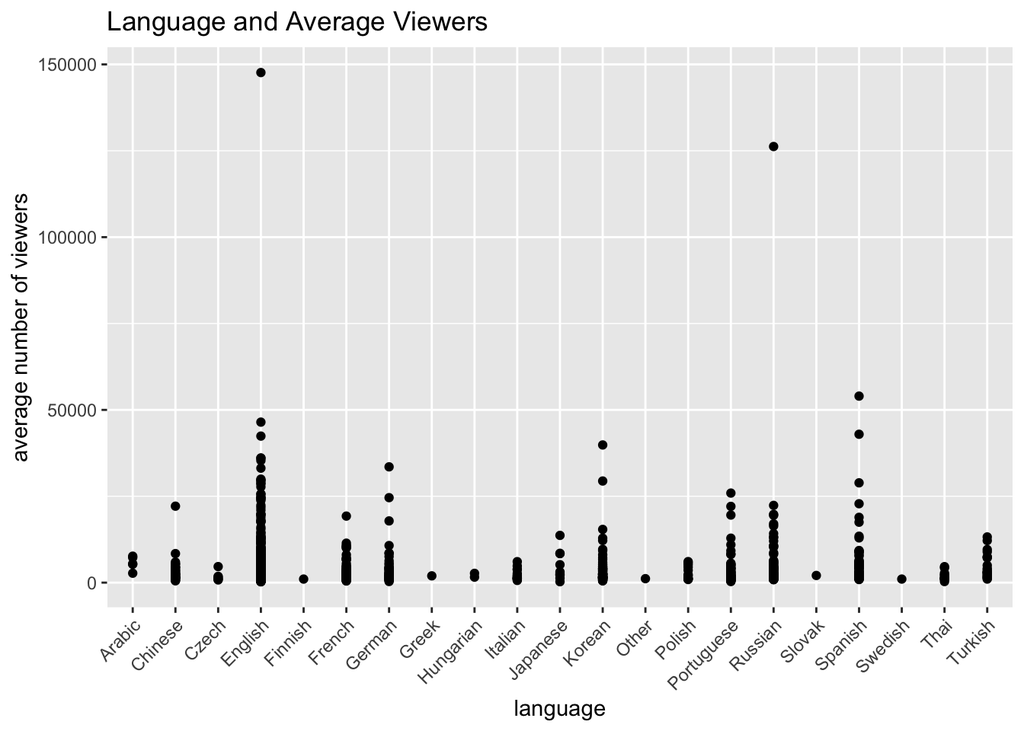

```r
ggplot(twitch_data, aes(language, average_viewers)) +
  geom_point() +
  labs(title = "Language and Average Viewers",
       y = "average number of viewers") +
  theme(axis.text.x = element_text(angle = 45, hjust = 1))
```

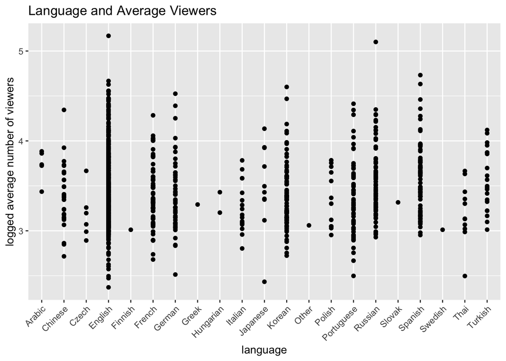

```r
ggplot(twitch_data, aes(language, log_viewers)) +
  geom_point() +
  labs(title = "Language and Average Viewers",
       y = "logged average number of viewers") +
  theme(axis.text.x = element_text(angle = 45, hjust = 1))
```

I don’t really see much, but I am not sure what would be helpful in this instance.

### **Q4**

```r
#setting English as reference category
twitch_data <- twitch_data %>%
  mutate(language = as.factor(language),
         language = relevel(language, ref = "English"))

##changing the values of the languages to #'s
twitch_data <- twitch_data %>%
  mutate(language_factor = case_when(
         language == "English" ~ 1,
         language == "Arabic" ~ 2,
         language == "Chinese" ~ 3,
         language == "Czech" ~ 4,
         language == "Finnish" ~ 5,
         language == "French" ~ 6,
         language == "German" ~ 7,
         language == "Greek" ~ 8,
         language == "Hungarian" ~ 9,
         language == "Italian" ~ 10,
         language == "Japanese" ~ 11,
         language == "Korean" ~ 12,
         language == "Polish" ~ 13,
         language == "Portuguese" ~ 14,
         language == "Russian" ~ 15,
         language == "Slovak" ~ 16,
         language == "Spanish" ~ 17,
         language == "Swedish" ~ 18,
         language == "Thai" ~ 19,
         language == "Turkish" ~ 20,
         language == "Other" ~ 21)
         )

fit2 <-
  lm(data = twitch_data,
     formula = log_viewers ~ language_factor)


pred_data2 <- augment(fit2)
fit2
```

```
##
## Call:
## lm(formula = log_viewers ~ language_factor, data = twitch_data)
##
## Coefficients:
##     (Intercept)  language_factor
##       3.4448559        0.0008428
```

```r
View(pred_data2)
```

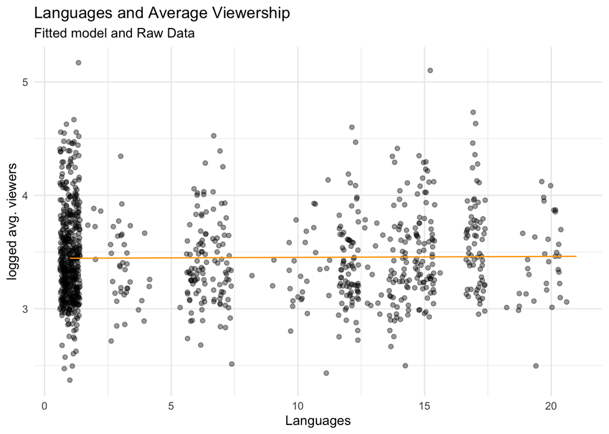

```r
pred_data2 %>%
  ggplot(aes(language_factor,
             log_viewers)) +
  geom_jitter(alpha = 0.4) +
  geom_line(aes(x = language_factor,
                y = .fitted),
            col = "orange") +
  theme_minimal() +
  labs(title = "Languages and Average Viewership",
       subtitle = "Fitted model and Raw Data",
       x = "Languages",
       y = "logged avg. viewers")
```